# Business Statistics Analysis

Rody

```r
library(tidyverse)
library(gridExtra)
```

# Cardiovascular Disease Analysis

This analysis examines the regional factors associated with Cardiovascular Disease (CVD) prevalence across local authority regions in England.

The analysis includes:

1. A descriptive summary of CVD prevalence and the key explanatory variables.
2. A visualisation of the relationship between poverty and CVD prevalence.
3. A correlation analysis examining the association between poverty and CVD prevalence.
4. A multiple regression analysis examining the associations between overweight prevalence, smoking prevalence, poverty, wellbeing, and CVD prevalence.
5. Regression diagnostics to assess the assumptions of the multiple regression model.

## Data Dictionary

This dataset is from the UK Office for National Statistics. The variables are described in the table below.

| Variable | Description |
| --- | --- |
| area_name | Name of the local authority region |
| area_code | Unique code identifying the local authority region |
| Population | Total population living in the area |
| Poverty | Percentage of the population living in poverty in the area |
| CVD | Percentage of people in the area who have recently experienced Cardiovascular Disease (CVD) |
| overweight | Percentage of people in the area classified as overweight |
| smokers | Percentage of people in the area who smoke |
| wellbeing | Average wellbeing score of people living in the area |

## Read Data and Data quality checks

```r
# Load the dataset
cvd_data <- read_csv("Cardio_Vascular_Disease.csv")
## Check structure and column types
str(cvd_data)
```

```
## spc_tbl_ [385 × 8] (S3: spec_tbl_df/tbl_df/tbl/data.frame)
##  $ area_name : chr [1:385] "Hartlepool" "Middlesbrough" "Redcar and Cleveland" "Stockton-on-Tees" ...
##  $ area_code : chr [1:385] "E06000001" "E06000002" "E06000003" "E06000004" ...
##  $ Population: num [1:385] 88905 133375 131035 186365 104300 ...
##  $ Poverty   : num [1:385] 23 25.1 21.4 19.5 19.7 21.9 17.9 24.9 26.1 22.4 ...
##  $ CVD       : num [1:385] 13.7 13.1 15 12.4 11.9 15.7 12 13.4 17.6 11.2 ...
##  $ overweight: num [1:385] 34.6 32 33.4 40.2 35.7 ...
##  $ smokers   : num [1:385] 17.3 17.9 13.3 12.5 10.6 13.2 10 15.5 20.6 22 ...
##  $ wellbeing : num [1:385] 7.33 7.21 7.44 7.4 7.25 7.29 7.21 7.43 7.16 7.14 ...
##  - attr(*, "spec")=
##   .. cols(
##   ..   area_name = col_character(),
##   ..   area_code = col_character(),
##   ..   Population = col_double(),
##   ..   Poverty = col_double(),
##   ..   CVD = col_double(),
##   ..   overweight = col_double(),
##   ..   smokers = col_double(),
##   ..   wellbeing = col_double()
##   .. )
##  - attr(*, "problems")=<externalptr>
```

```r
# Summary statistics to identify missing and extreme values
summary(cvd_data)
```

```
##   area_name          area_code           Population         Poverty
##  Length:385         Length:385         Min.   :   1960   Min.   :12.90
##  Class :character   Class :character   1st Qu.: 100640   1st Qu.:16.90
##  Mode  :character   Mode  :character   Median : 135275   Median :18.70
##                                        Mean   : 174804   Mean   :19.34
##                                        3rd Qu.: 216600   3rd Qu.:21.40
##                                        Max.   :1056970   Max.   :30.70
##                                        NA's   :76        NA's   :76
##       CVD          overweight       smokers        wellbeing
##  Min.   : 7.90   Min.   :10.24   Min.   : 3.20   Min.   :6.610
##  1st Qu.:10.90   1st Qu.:21.63   1st Qu.:10.72   1st Qu.:7.280
##  Median :12.30   Median :25.52   Median :12.80   Median :7.410
##  Mean   :12.42   Mean   :25.52   Mean   :13.07   Mean   :7.423
##  3rd Qu.:14.10   3rd Qu.:29.46   3rd Qu.:15.30   3rd Qu.:7.560
##  Max.   :17.80   Max.   :40.22   Max.   :27.80   Max.   :8.170
##  NA's   :76      NA's   :72      NA's   :7       NA's   :15
```

```r
# Check for missing values
missing_summary <- summarise_all(cvd_data, ~ sum(is.na(.x)))
missing_summary
```

```
## # A tibble: 1 × 8
##   area_name area_code Population Poverty   CVD overweight smokers wellbeing
##       <int>     <int>      <int>   <int> <int>      <int>   <int>     <int>
## 1         0         0         76      76    76         72       7        15
```

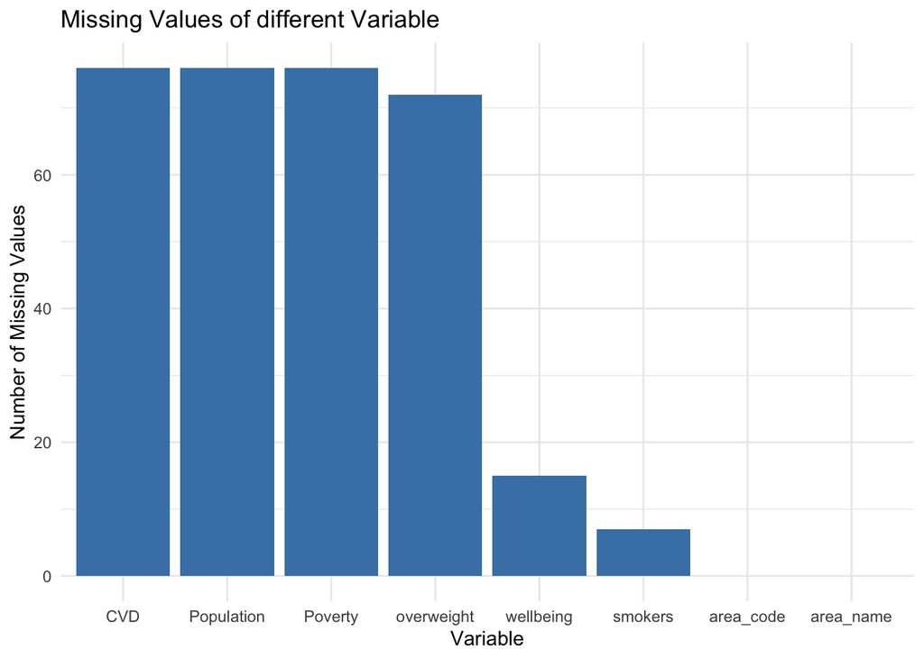

```r
# Handle missing values by removing rows with NAs
cvd_data_clean <- cvd_data %>% drop_na()

# Visualize missing data with a bar chart
missing_data <- data.frame(Variable = names(missing_summary), MissingValues = as.numeric(missing_summary[1, ]))
ggplot(missing_data, aes(x = reorder(Variable, -MissingValues), y = MissingValues)) +
  geom_bar(stat = "identity", fill = "steelblue") +
  labs(title = "Missing Values of different Variable", x = "Variable", y = "Number of Missing Values") +
  theme_minimal()
```

```r
# Identify outliers in CVD prevalence (e.g., top 5% values)
outliers_cvd <- cvd_data_clean %>% filter(CVD > quantile(CVD, 0.95))
outliers_cvd
```

```
## # A tibble: 15 × 8
##    area_name     area_code Population Poverty   CVD overweight smokers wellbeing
##    <chr>         <chr>          <dbl>   <dbl> <dbl>      <dbl>   <dbl>     <dbl>
##  1 Blackpool     E06000009     134135    26.1  17.6       37.2    20.6      7.16
##  2 Torbay        E06000027     132270    21.3  16.5       28.1    15.4      7.34
##  3 Copeland      E07000029      65795    20.4  16.1       27.0    17.8      7.84
##  4 Eden          E07000030      52400    19    16.3       18.8     8.2      7.59
##  5 South Lakela… E07000031      99810    17.5  17         18.0    10.4      7.79
##  6 West Devon    E07000047      54325    18.5  16         22.3    13.9      7.81
##  7 Rother        E07000064      90195    20.5  16.5       28.8    16.7      7.63
##  8 Lancaster     E07000121     131085    20    16.9       30.2    13.6      7.74
##  9 Wyre          E07000128     107175    19    17.8       26.7    11.4      7.98
## 10 North Norfolk E07000147      99650    19.5  16.4       26.5    13.2      7.76
## 11 Sedgemoor     E07000188     121870    19.3  16         27.1    17.3      7.65
## 12 South Somers… E07000189     166555    18.6  16.5       24.6    13.6      7.52
## 13 Staffordshir… E07000198      94005    14.6  16.6       27.5     8.5      7.76
## 14 Somerset Wes… E07000246     151290    18.7  16.3       21.6    17.3      7.65
## 15 South Tynesi… E08000023     143225    21.9  16.3       33.4    16.3      7.29
```

## Visualisation of continuous variables

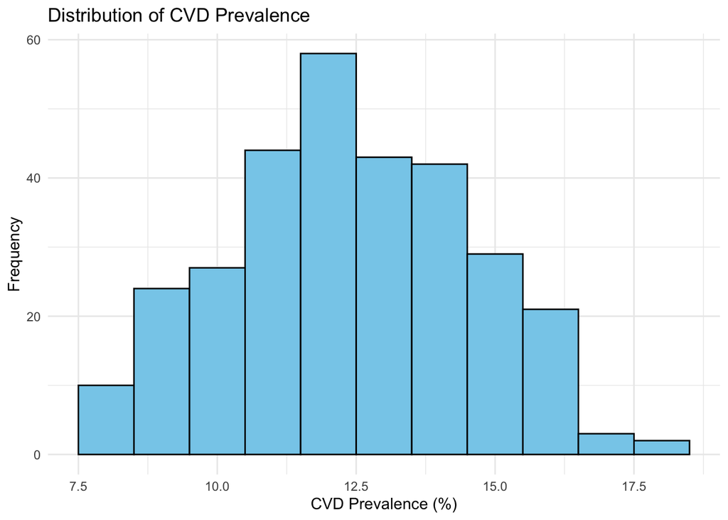

```r
# Visualize the distribution of CVD prevalence
ggplot(cvd_data_clean, aes(x = CVD)) +
  geom_histogram(binwidth = 1, fill = "skyblue", color = "black") +
  labs(title = "Distribution of CVD Prevalence", x = "CVD Prevalence (%)", y = "Frequency") +
  theme_minimal()
```

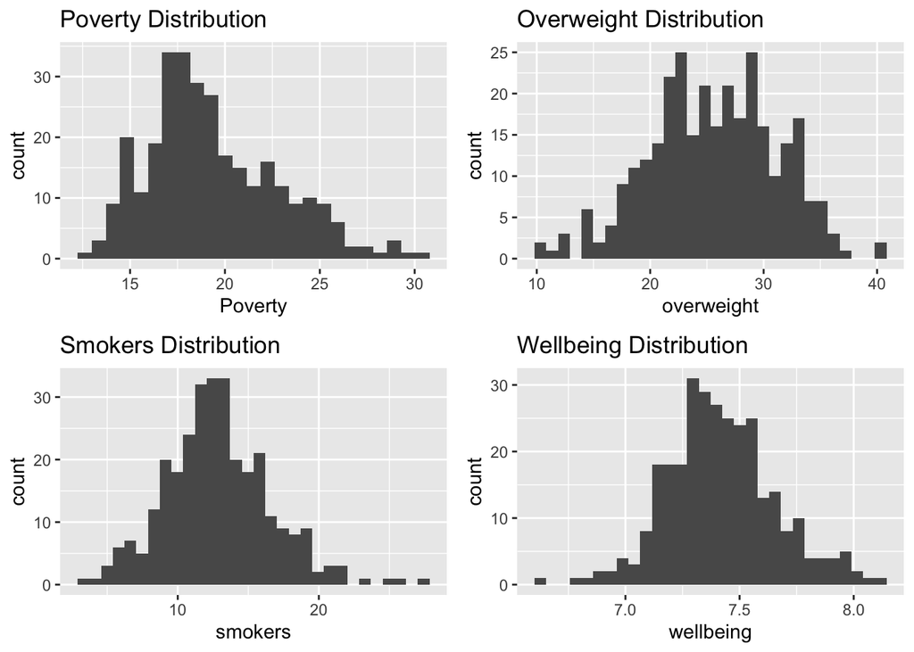

```r
# Visualize distributions of other key variables
grid.arrange(
  ggplot(cvd_data_clean) + geom_histogram(aes(Poverty), bins = 25) + labs(title = "Poverty Distribution"),
  ggplot(cvd_data_clean) + geom_histogram(aes(overweight), bins = 30) + labs(title = "Overweight Distribution"),
  ggplot(cvd_data_clean) + geom_histogram(aes(smokers), bins = 30) + labs(title = "Smokers Distribution"),
  ggplot(cvd_data_clean) + geom_histogram(aes(wellbeing), bins = 30) + labs(title = "Wellbeing Distribution"),
  ncol = 2
)
```

## Check the discrete and categorical data

```r
# Count the number of rows for each unique value in the 'area_name' column
arrange(count(cvd_data, area_name), desc(n))
```

```
## # A tibble: 385 × 2
##    area_name                                n
##    <chr>                                <int>
##  1 Aberdeen City                            1
##  2 Aberdeenshire                            1
##  3 Adur                                     1
##  4 Allerdale                                1
##  5 Amber Valley                             1
##  6 Angus                                    1
##  7 Antrim and Newtownabbey                  1
##  8 Ards and North Down                      1
##  9 Argyll and Bute                          1
## 10 Armagh City, Banbridge and Craigavon     1
## # ℹ 375 more rows
```

```r
## Check for any duplicate or inconsistent area names.

# Count the number of unique 'area_code' values (categorical data)
arrange(count(cvd_data, area_code), desc(n))
```

```
## # A tibble: 385 × 2
##    area_code     n
##    <chr>     <int>
##  1 E06000001     1
##  2 E06000002     1
##  3 E06000003     1
##  4 E06000004     1
##  5 E06000005     1
##  6 E06000006     1
##  7 E06000007     1
##  8 E06000008     1
##  9 E06000009     1
## 10 E06000010     1
## # ℹ 375 more rows
```

```r
## Each 'area_code' should uniquely identify a region. Ensure no duplicates.

# Check for the distribution of CVD prevalence across regions
count(cvd_data_clean, CVD) %>%
  arrange(desc(n))
```

```
## # A tibble: 86 × 2
##      CVD     n
##    <dbl> <int>
##  1  11.9    12
##  2  10.7     8
##  3  11.3     7
##  4  13       7
##  5  14.3     7
##  6  10.2     6
##  7  11.7     6
##  8  11.8     6
##  9  12       6
## 10  12.2     6
## # ℹ 76 more rows
```

```r
## The frequency of specific CVD prevalence values across regions.

# Check for distributions of discrete variables: Population groupings
summary(cvd_data_clean$Population)
```

```
##    Min. 1st Qu.  Median    Mean 3rd Qu.    Max.
##   36890  101225  135540  175327  214975 1056970
```

```r
## Summarize population data to identify any outliers or unusual values.

# Count regions by poverty group
poverty_bins <- cvd_data_clean %>%
  mutate(Poverty_Group = case_when(
    Poverty < 10 ~ "Low",
    Poverty >= 10 & Poverty < 20 ~ "Moderate",
    Poverty >= 20 ~ "High"
  ))
arrange(count(poverty_bins, Poverty_Group), desc(n))
```

```
## # A tibble: 2 × 2
##   Poverty_Group     n
##   <chr>         <int>
## 1 Moderate        194
## 2 High            109
```

```r
## Verify the distribution of regions across different poverty levels.

# Check for overweight groupings
overweight_bins <- cvd_data_clean %>%
  mutate(Overweight_Group = case_when(
    overweight < 30 ~ "Low",
    overweight >= 30 & overweight < 40 ~ "Moderate",
    overweight >= 40 ~ "High"
  ))
arrange(count(overweight_bins, Overweight_Group), desc(n))
```

```
## # A tibble: 3 × 2
##   Overweight_Group     n
##   <chr>            <int>
## 1 Low                235
## 2 Moderate            66
## 3 High                 2
```

```r
## Assess prevalence of overweight categories across regions.

# Check for smoking prevalence groupings
smokers_bins <- cvd_data_clean %>%
  mutate(Smokers_Group = case_when(
    smokers < 15 ~ "Low",
    smokers >= 15 & smokers < 25 ~ "Moderate",
    smokers >= 25 ~ "High"
  ))
arrange(count(smokers_bins, Smokers_Group), desc(n))
```

```
## # A tibble: 3 × 2
##   Smokers_Group     n
##   <chr>         <int>
## 1 Low             225
## 2 Moderate         76
## 3 High              2
```

```r
## Evaluate the spread of smoking rates across the dataset.
```

## Data Cleaning

```r
# Retain complete observations for the variables used in the analysis
cvd_data_clean <- cvd_data %>%
  filter(
    !is.na(CVD),
    !is.na(Poverty),
    !is.na(overweight),
    !is.na(smokers),
    !is.na(wellbeing),
    !is.na(Population)
  )

# Confirm the number of observations retained
nrow(cvd_data_clean)
```

```
## [1] 303
```

The original dataset contained **385 regional observations**. Missing values were identified across several variables, including CVD, poverty, population, overweight prevalence, smoking prevalence, and wellbeing.

For the statistical analyses, observations with missing values in the variables required for the analysis were excluded, resulting in **303 complete observations**.

Although some regions had relatively high CVD prevalence, these observations were retained because there was no evidence that they represented data-entry errors or invalid measurements. This avoids removing potentially meaningful regional variation solely on the basis of high observed CVD values.

## Exploratory and Statistical Analysis

### 1. Descriptive Analysis of CVD and Related Variables

```r
# Summary statistics of key variables
summary_stats <- cvd_data_clean %>%
  summarise(
    Mean_CVD = mean(CVD, na.rm = TRUE),
    SD_CVD = sd(CVD, na.rm = TRUE),
    Mean_Overweight = mean(overweight, na.rm = TRUE),
    SD_Overweight = sd(overweight, na.rm = TRUE),
    Mean_Smokers = mean(smokers, na.rm = TRUE),
    SD_Smokers = sd(smokers, na.rm = TRUE),
    Mean_Wellbeing = mean(wellbeing, na.rm = TRUE),
    SD_Wellbeing = sd(wellbeing, na.rm = TRUE),
    Mean_Poverty = mean(Poverty, na.rm = TRUE),
    SD_Poverty = sd(Poverty, na.rm = TRUE)
  )
summary_stats
```

```
## # A tibble: 1 × 10
##   Mean_CVD SD_CVD Mean_Overweight SD_Overweight Mean_Smokers SD_Smokers
##      <dbl>  <dbl>           <dbl>         <dbl>        <dbl>      <dbl>
## 1     12.4   2.17            25.5          5.61         12.9       3.77
## # ℹ 4 more variables: Mean_Wellbeing <dbl>, SD_Wellbeing <dbl>,
## #   Mean_Poverty <dbl>, SD_Poverty <dbl>
```

### 2. Visualization of the Relationship Between Poverty and CVD

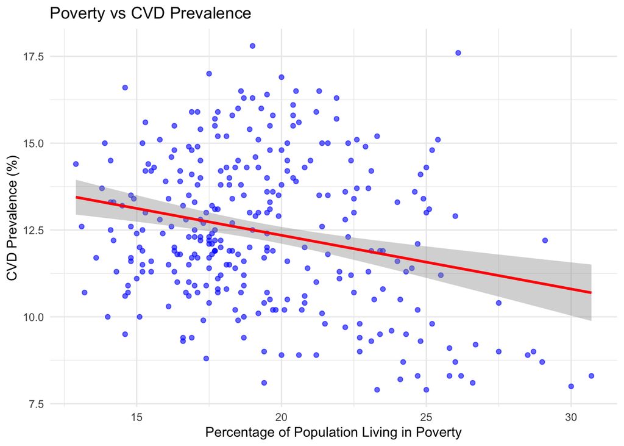

```r
cvd_data_clean$Poverty <- as.numeric(cvd_data_clean$Poverty)
cvd_data_clean$CVD <- as.numeric(cvd_data_clean$CVD)
cvd_data_clean <- na.omit(cvd_data_clean)

ggplot(cvd_data_clean, aes(x = Poverty, y = CVD)) +
  geom_point(color = "blue", alpha = 0.6) +
  geom_smooth(method = "lm", formula = y ~ x, color = "red", se = TRUE) +
  labs(title = "Poverty vs CVD Prevalence",
       x = "Percentage of Population Living in Poverty",
       y = "CVD Prevalence (%)") +
  theme_minimal()
```

```r
# Test the linear association between poverty and CVD prevalence
cor.test(cvd_data_clean$Poverty, cvd_data_clean$CVD)
```

```
##
##  Pearson's product-moment correlation
##
## data:  cvd_data_clean$Poverty and cvd_data_clean$CVD
## t = -4.443, df = 301, p-value = 1.248e-05
## alternative hypothesis: true correlation is not equal to 0
## 95 percent confidence interval:
##  -0.3509518 -0.1393000
## sample estimates:
##        cor
## -0.2480841
```

The scatter plot illustrates the relationship between the percentage of the population living in poverty and CVD prevalence across regions in England. Each point represents a region, while the fitted regression line shows the overall linear trend.

The results indicate a **negative relationship between poverty and CVD prevalence**, with regions reporting higher poverty rates tending to have lower observed CVD prevalence. Pearson’s correlation confirmed a **statistically significant negative association** (**r = -.248, p < .001**).

However, the correlation is relatively modest and should **not be interpreted as evidence that higher poverty causes lower CVD prevalence**. Other demographic, socioeconomic, or health-related factors may contribute to the observed relationship.

### 3. Multiple Regression Analysis

```r
# Fit a multiple linear regression model to examine factors associated with CVD prevalence
cvd_model <- lm(
  CVD ~ overweight + smokers + Poverty + wellbeing,
  data = cvd_data_clean
)

# Display regression results
summary(cvd_model)
```

```
##
## Call:
## lm(formula = CVD ~ overweight + smokers + Poverty + wellbeing,
##     data = cvd_data_clean)
##
## Residuals:
##     Min      1Q  Median      3Q     Max
## -4.3966 -1.4313 -0.1097  1.3905  4.7779
##
## Coefficients:
##             Estimate Std. Error t value Pr(>|t|)
## (Intercept) -1.69780    3.93361  -0.432 0.666335
## overweight   0.10985    0.02123   5.174 4.22e-07 ***
## smokers      0.12030    0.03366   3.574 0.000410 ***
## Poverty     -0.18400    0.03515  -5.234 3.13e-07 ***
## wellbeing    1.80025    0.49096   3.667 0.000291 ***
## ---
## Signif. codes:  0 '***' 0.001 '**' 0.01 '*' 0.05 '.' 0.1 ' ' 1
##
## Residual standard error: 1.894 on 298 degrees of freedom
## Multiple R-squared:  0.2494, Adjusted R-squared:  0.2393
## F-statistic: 24.75 on 4 and 298 DF,  p-value: < 2.2e-16
```

The multiple regression model was **statistically significant**, *F*(4, 298) = 24.75, **p < .001**, and explained approximately **24.9% of the variation in CVD prevalence** (R² = .249; adjusted R² = .239).

After controlling for the other variables in the model, **overweight prevalence was significantly positively associated with CVD prevalence** (**b = 0.110, p < .001**), indicating that regions with higher levels of overweight tended to have higher CVD prevalence.

**Smoking prevalence was also significantly positively associated with CVD prevalence** (**b = 0.120, p < .001**), suggesting that regions with higher smoking prevalence tended to have higher CVD prevalence after accounting for the other predictors.

In contrast, **poverty showed a statistically significant negative association with CVD prevalence** (**b = -0.184, p < .001**). This indicates that, within this dataset and after controlling for overweight, smoking, and wellbeing, regions with higher poverty rates tended to have lower observed CVD prevalence.

**Wellbeing was significantly positively associated with CVD prevalence** (**b = 1.800, p < .001**). After controlling for the other predictors, regions with higher average wellbeing scores tended to have higher observed CVD prevalence.

Overall, **overweight, smoking, poverty, and wellbeing were all statistically significant predictors of CVD prevalence** in the model. These findings describe statistical associations and **should not be interpreted as evidence of causal relationships**.

### 4. Regression Diagnostics

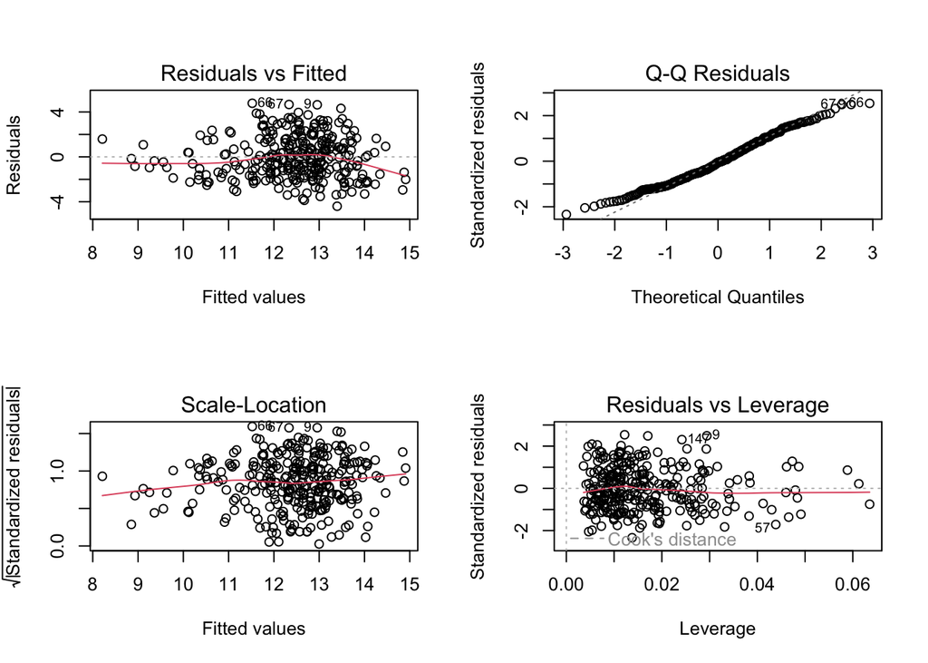

```r
# Diagnostic plots for the multiple regression model
par(mfrow = c(2, 2))
plot(cvd_model)
```

```r
par(mfrow = c(1, 1))
```

The regression diagnostic plots suggest that the model assumptions are **reasonably satisfied, although some minor deviations are present**.

The **Residuals vs Fitted** plot shows some curvature in the residual pattern, suggesting possible mild non-linearity. The **Q-Q plot** indicates that the residuals follow the expected distribution reasonably well across most observations, although some deviations are visible in the tails.

The **Scale-Location** plot suggests some variation in residual spread across fitted values, indicating possible mild heteroscedasticity. The **Residuals vs Leverage** plot identifies a small number of observations with relatively higher leverage, but no clearly extreme influential observations are apparent from the diagnostic plot.

Overall, the diagnostic results do not indicate severe violations that would invalidate the regression analysis, but the **minor departures from linearity, normality, and constant variance should be considered when interpreting the model estimates**.

## Descriptive Statistics

Table 1 presents descriptive statistics for the key demographic and health-related variables included in the analysis.

Table 1. Summary of demographic and health-related variables

| Variable | Mean | SD | Min | Max |
| --- | --- | --- | --- | --- |
| CVD (%) | 12.45 | 2.17 | 7.90 | 17.80 |
| Poverty (%) | 19.36 | 3.48 | 12.90 | 30.70 |
| Overweight (%) | 25.54 | 5.61 | 10.24 | 40.22 |
| Smokers (%) | 12.87 | 3.77 | 3.70 | 27.80 |
| Wellbeing | 7.42 | 0.24 | 6.61 | 8.10 |

Table 1 summarises the key demographic and health-related variables across the **303 regions included in the analysis**.

The mean **CVD prevalence was 12.45%** (SD = 2.17), ranging from **7.90% to 17.80%**. The average **poverty rate was 19.36%** (SD = 3.48), with values ranging from 12.90% to 30.70%.

The mean **overweight prevalence was 25.54%** (SD = 5.61), while the mean **smoking prevalence was 12.87%** (SD = 3.77). The average **wellbeing score was 7.42** (SD = 0.24).

These descriptive statistics indicate substantial regional variation in CVD prevalence and several of the health and socioeconomic factors examined in the subsequent regression analysis.

## Summary

The analysis identified significant associations between **CVD prevalence and all four factors examined: overweight prevalence, smoking prevalence, poverty, and wellbeing**. The multiple regression model was statistically significant and explained approximately **24.9% of the variation in CVD prevalence** across the regions (R² = .249).

After controlling for the other predictors, **higher overweight prevalence** (**b = 0.110, p < .001**) and **higher smoking prevalence** (**b = 0.120, p < .001**) were significantly associated with **higher CVD prevalence**.

In contrast, **poverty was significantly negatively associated with CVD prevalence** (**b = -0.184, p < .001**). This finding was consistent with the bivariate analysis, which also showed a statistically significant negative correlation between poverty and CVD prevalence (**r = -.248, p < .001**).

**Wellbeing was significantly positively associated with CVD prevalence** after controlling for the other predictors (**b = 1.800, p < .001**). Although this direction may appear counterintuitive, the analysis does not establish why this relationship occurs, and it should therefore be interpreted cautiously.

Overall, the findings suggest that **regional differences in overweight prevalence, smoking prevalence, poverty, and wellbeing are all statistically associated with CVD prevalence** in this dataset. However, the model explains only part of the regional variation in CVD, indicating that **additional factors not included in the analysis are also likely to be relevant**. As this analysis is based on observational regional-level data, the results represent **associations rather than causal effects**. ***

# Customer Satisfaction Analysis

This analysis examines the factors associated with customer satisfaction across furniture retail stores, with a particular focus on the relationship between delivery time and socio-economic status (SES).

The analysis includes:

1. A descriptive summary of customer satisfaction, staff satisfaction, delivery time, product range status, and socio-economic status (SES).
2. A visualisation of the distribution of delivery times across stores.
3. A multiple regression analysis examining the relationship between delivery time, staff satisfaction, product range status, SES, and customer satisfaction.
4. An interaction analysis examining whether the relationship between delivery time and customer satisfaction varies across SES groups.

## Data Dictionary

The dataset contains store-level customer satisfaction and operational information from a furniture retail company.

| Variable | Description |
| --- | --- |
| SES_category | Socio-economic status category of the store (e.g., Low, Medium, High) |
| customer.satisfaction | Average customer satisfaction score for the store |
| staff.satisfaction | Average staff job satisfaction score for the store |
| delivery.time | Average delivery time for large and custom items |
| new_range | Indicates whether the store was carrying a new range of products (TRUE/FALSE) |

## Read Data and Data quality checks

```r
cust_data <- read.csv("cust_satisfaction.csv")

# Inspect the data
str(cust_data)
```

```
## 'data.frame':    300 obs. of  5 variables:
##  $ SES_category         : chr  "Medium" "Medium" "Medium" "High" ...
##  $ customer.satisfaction: num  7.27 7.93 7.12 6.35 6.78 ...
##  $ staff.satisfaction   : num  6.88 7.44 7.15 6.47 7.06 ...
##  $ delivery.time        : num  66.7 68.2 70.7 61.4 57.7 ...
##  $ new_range            : logi  FALSE FALSE FALSE TRUE TRUE TRUE ...
```

```r
# Summary of the dataset
summary(cust_data)
```

```
##  SES_category       customer.satisfaction staff.satisfaction delivery.time
##  Length:300         Min.   :3.760         Min.   :4.850      Min.   :32.96
##  Class :character   1st Qu.:6.099         1st Qu.:6.216      1st Qu.:52.46
##  Mode  :character   Median :7.006         Median :6.634      Median :60.45
##                     Mean   :6.930         Mean   :6.751      Mean   :59.60
##                     3rd Qu.:7.865         3rd Qu.:7.274      3rd Qu.:66.79
##                     Max.   :9.670         Max.   :8.860      Max.   :92.48
##  new_range
##  Mode :logical
##  FALSE:142
##  TRUE :158
##
##
##
```

```r
# Check for missing values
missing_summary <- summarise_all(cust_data, ~ sum(is.na(.x)))
missing_summary
```

```
##   SES_category customer.satisfaction staff.satisfaction delivery.time new_range
## 1            0                     0                  0             0         0
```

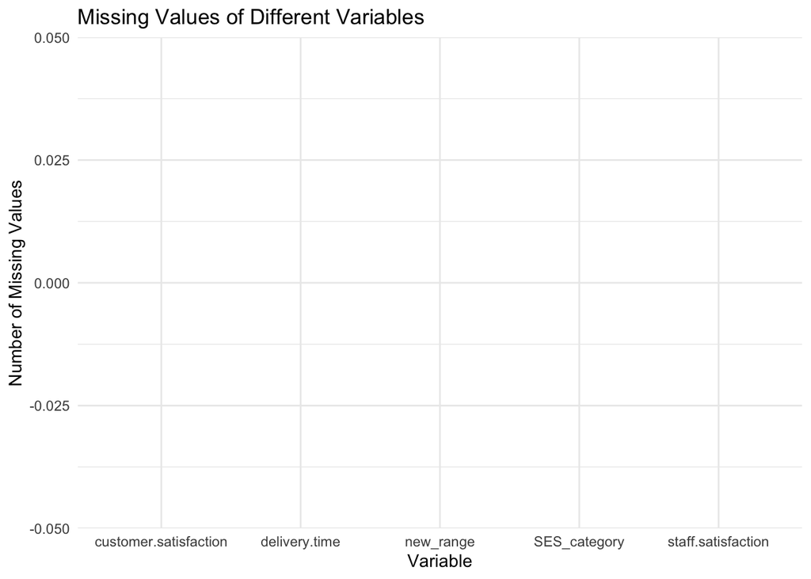

```r
# No missing values were identified; retain all observations for analysis
cust_data_clean <- cust_data

# Visualize missing data with a bar chart
missing_data <- data.frame(Variable = names(missing_summary), MissingValues = as.numeric(missing_summary[1, ]))
ggplot(missing_data, aes(x = reorder(Variable, -MissingValues), y = MissingValues)) +
  geom_bar(stat = "identity", fill = "steelblue") +
  labs(title = "Missing Values of Different Variables", x = "Variable", y = "Number of Missing Values") +
  theme_minimal()
```

The dataset contained **300 store-level observations**, with **no missing values identified across the variables examined**. The SES categories were evenly represented, with **100 stores each in the High, Medium, and Low SES groups**. As no invalid SES categories or missing observations were identified, all 300 observations were retained for subsequent analysis.

## Visualisation of continuous variables

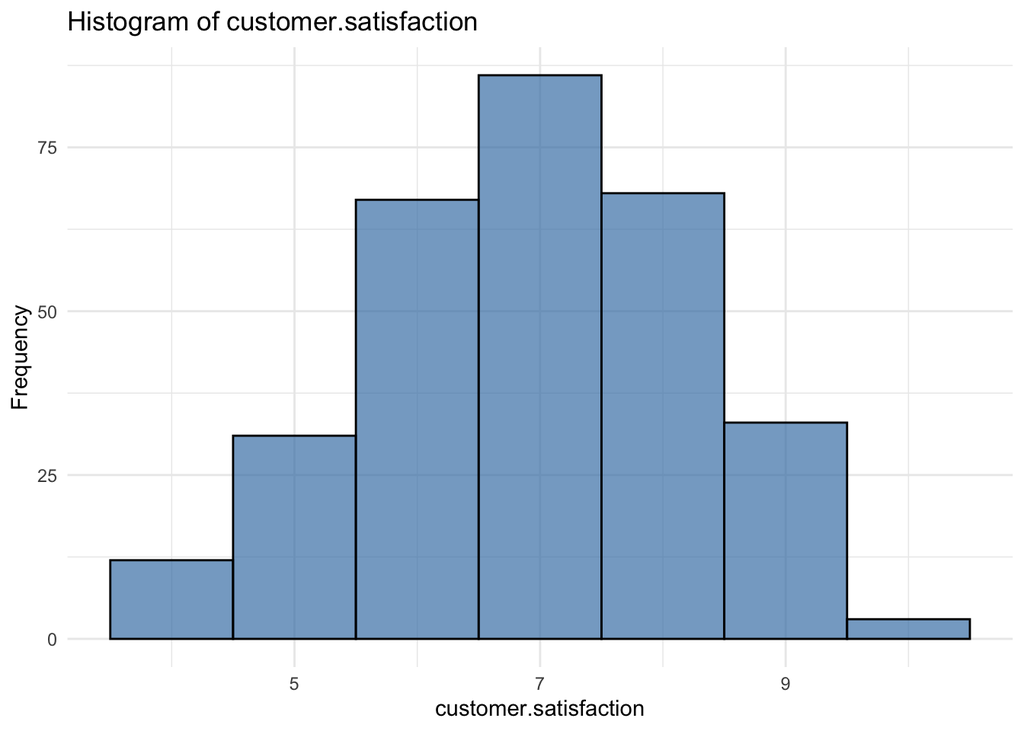

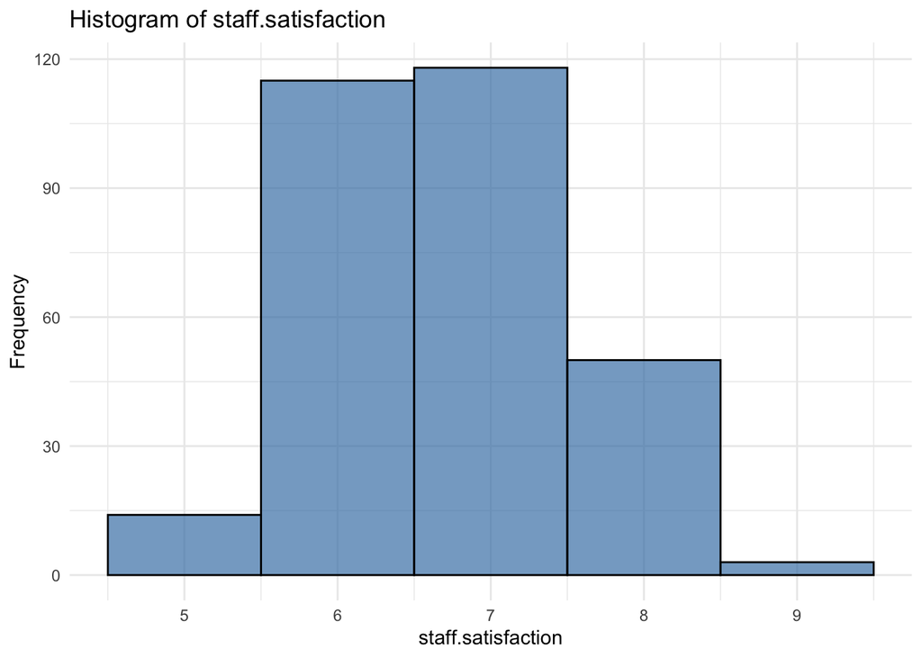

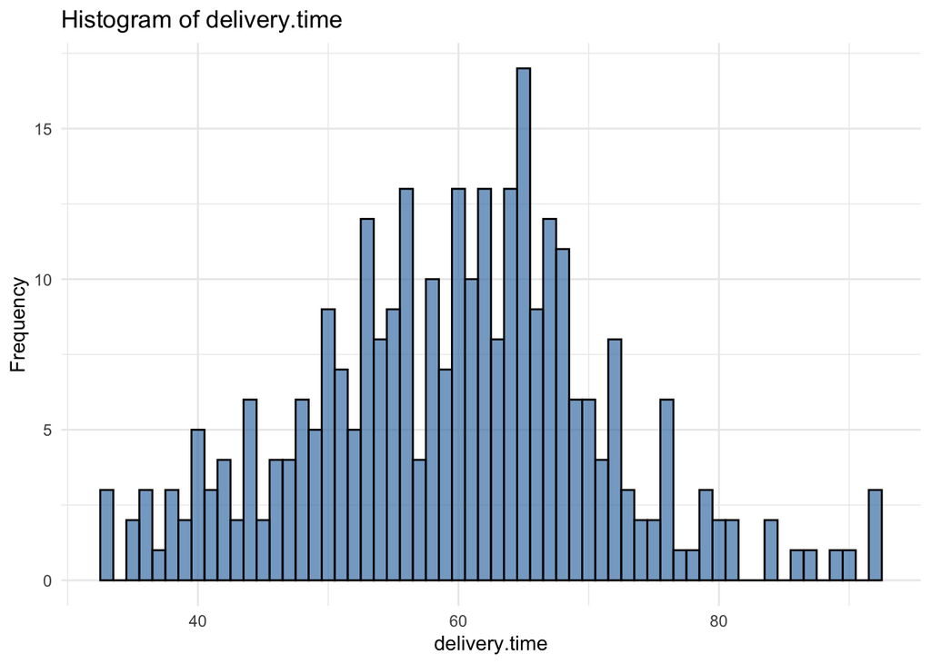

```r
# Define continuius variables
continuous_vars <- c("customer.satisfaction", "staff.satisfaction", "delivery.time")

# Histogram for each continuous variable
for (var in continuous_vars) {
  print(
    ggplot(cust_data_clean, aes_string(x = var)) +
      geom_histogram(binwidth = 1, fill = "steelblue", color = "black", alpha = 0.7) +
      labs(title = paste("Histogram of", var), x = var, y = "Frequency") +
      theme_minimal()
  )
}
```

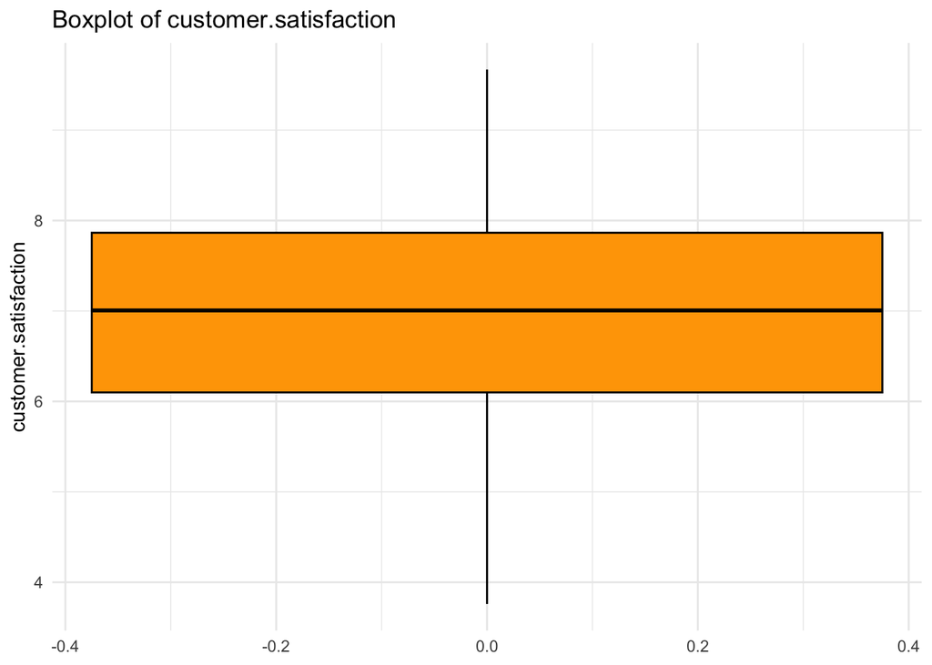

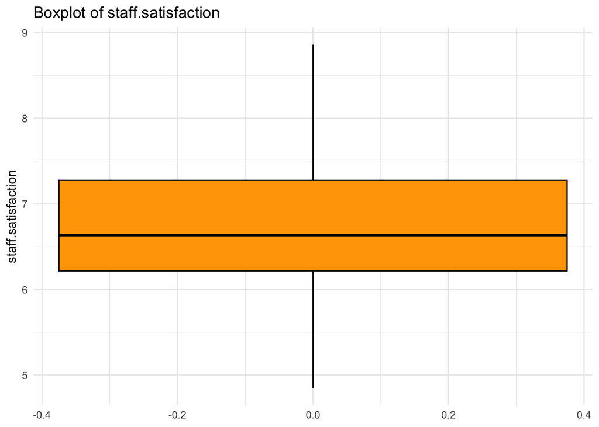

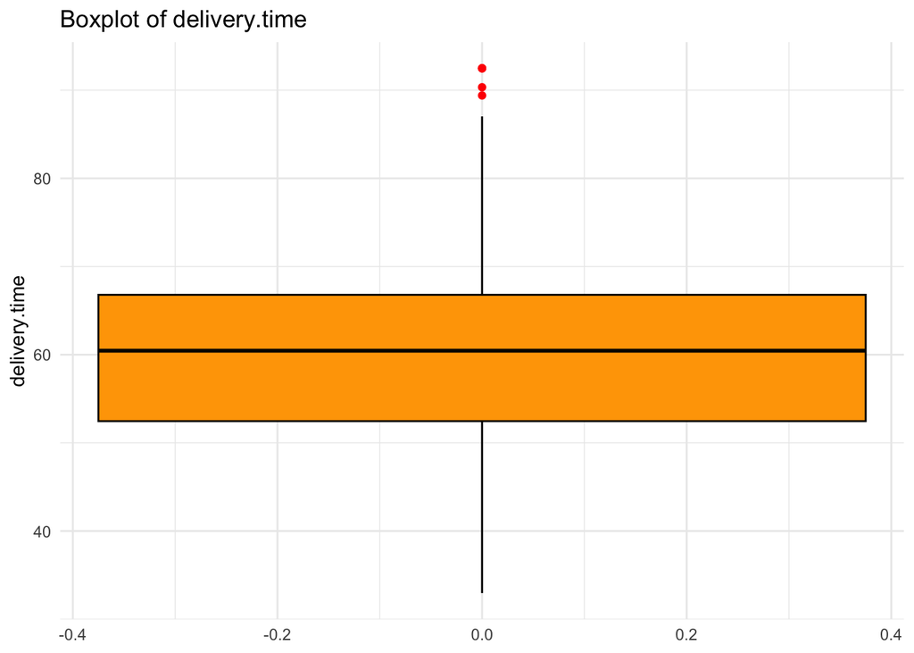

```r
# Boxplot to detect outliers
for (var in continuous_vars) {
  print(
    ggplot(cust_data_clean, aes_string(y = var)) +
      geom_boxplot(fill = "orange", color = "black", outlier.color = "red") +
      labs(title = paste("Boxplot of", var), y = var) +
      theme_minimal()
  )
}
```

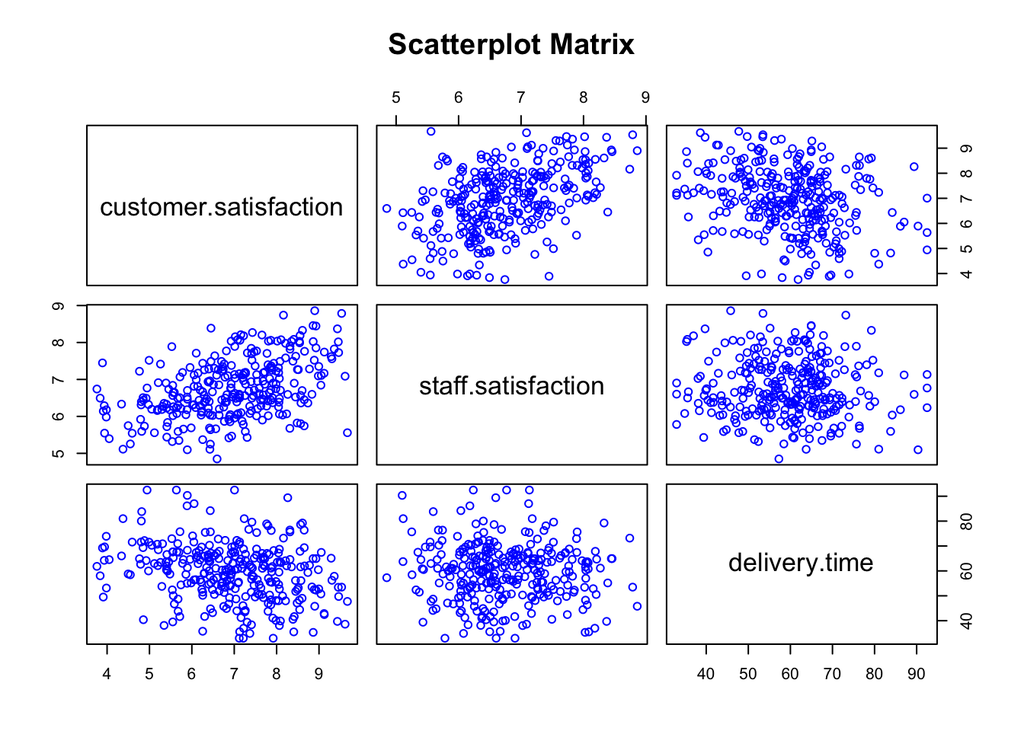

```r
# Scatterplot Matrix to view the relationship between variables
pairs(cust_data_clean[continuous_vars],
      main = "Scatterplot Matrix",
      col = "blue")
```

## Check the discrete and categorical data

```r
# Check the distribution of SES_category
arrange(count(cust_data_clean, SES_category), desc(n))
```

```
##   SES_category   n
## 1         High 100
## 2          Low 100
## 3       Medium 100
```

```r
# Check the distribution of new_range
arrange(count(cust_data_clean, new_range), desc(n))
```

```
##   new_range   n
## 1      TRUE 158
## 2     FALSE 142
```

## Exploratory and Statistical Analysis

### 1. Descriptive Analysis of Variables and Visualize the distribution.

```r
# Summary statistics
summary_stats <- cust_data_clean %>%
  summarise(
    Mean_Cust_Sat = mean(customer.satisfaction),
    SD_Cust_Sat = sd(customer.satisfaction),
    Median_Cust_Sat = median(customer.satisfaction),
    Mean_Staff_Sat = mean(staff.satisfaction),
    SD_Staff_Sat = sd(staff.satisfaction),
    Median_Delivery_Time = median(delivery.time),
    Mean_Delivery_Time = mean(delivery.time),
    SD_Delivery_Time = sd(delivery.time)
  )

# Print summary table
summary_stats
```

```
##   Mean_Cust_Sat SD_Cust_Sat Median_Cust_Sat Mean_Staff_Sat SD_Staff_Sat
## 1      6.929813    1.291654        7.006007       6.751263     0.786164
##   Median_Delivery_Time Mean_Delivery_Time SD_Delivery_Time
## 1             60.45249           59.59766         11.55637
```

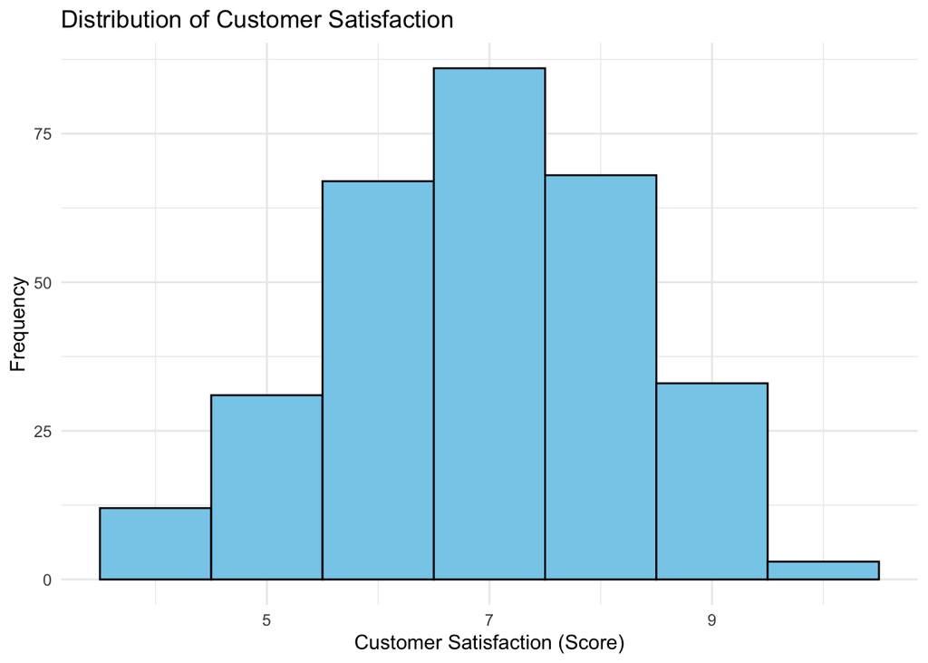

```r
# Visualize the distribution of customer satisfaction
ggplot(cust_data_clean, aes(x = customer.satisfaction)) +
  geom_histogram(binwidth = 1, fill = "skyblue", color = "black") +
  labs(title = "Distribution of Customer Satisfaction", x = "Customer Satisfaction (Score)", y = "Frequency") +
  theme_minimal()
```

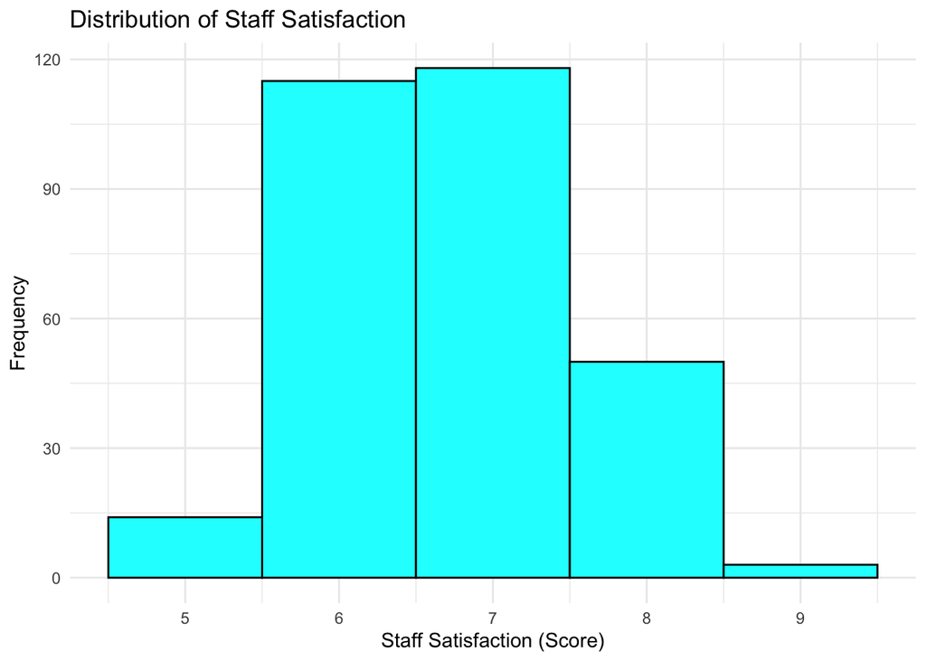

```r
# Visualize the distribution of staff satisfaction
ggplot(cust_data_clean, aes(x = staff.satisfaction)) +
  geom_histogram(binwidth = 1, fill = "cyan", color = "black") +
  labs(title = "Distribution of Staff Satisfaction", x = "Staff Satisfaction (Score)", y = "Frequency") + theme_minimal()
```

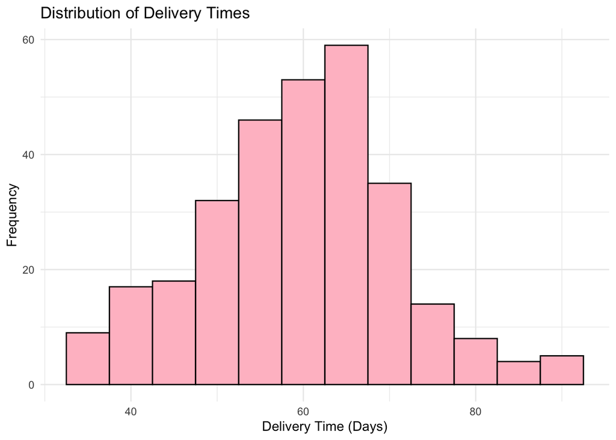

```r
# Visualize the distribution of Delivery Times
ggplot(cust_data_clean, aes(x = delivery.time)) +
  geom_histogram(binwidth = 5, fill = "pink", color = "black") +
  labs(title = "Distribution of Delivery Times", x = "Delivery Time (Days)", y = "Frequency") +
  theme_minimal()
```

```r
# Visualize the distribution of Product Range Status
new_range_counts <- cust_data_clean %>%
  count(new_range) # Count of stores carrying a new range of products

new_range_counts # Print the counts
```

```
##   new_range   n
## 1     FALSE 142
## 2      TRUE 158
```

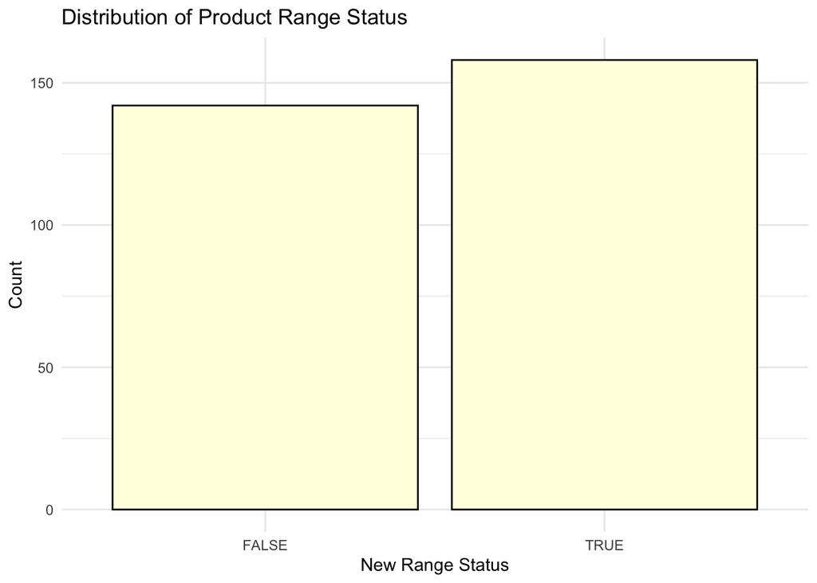

```r
ggplot(new_range_counts, aes(x = new_range, y = n)) +
  geom_bar(stat = "identity", fill = "lightyellow", color = "black") +
  labs(title = "Distribution of Product Range Status", x = "New Range Status", y = "Count") +
  theme_minimal()
```

```r
# Visualize the distribution of Socio-Economic Status (SES)
ses_counts <- cust_data_clean %>%
  count(SES_category) # Count of stores in each SES category

ses_counts # Print the counts
```

```
##   SES_category   n
## 1         High 100
## 2          Low 100
## 3       Medium 100
```

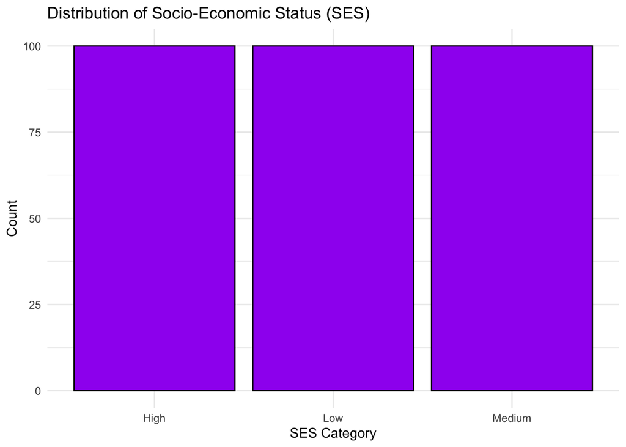

```r
ggplot(ses_counts, aes(x = SES_category, y = n)) +
  geom_bar(stat = "identity", fill = "purple", color = "black") +
  labs(title = "Distribution of Socio-Economic Status (SES)", x = "SES Category", y = "Count") +
  theme_minimal()
```

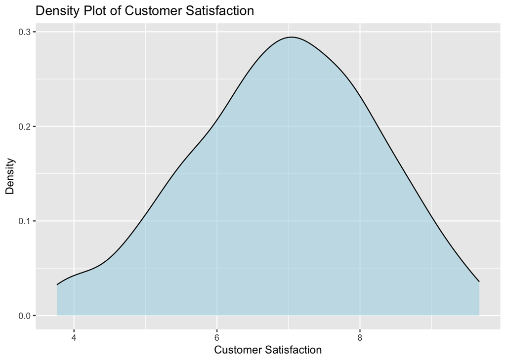

```r
# Visualize density plots for continuous variables to better capture distribution characteristics.
ggplot(cust_data_clean, aes(x = customer.satisfaction)) +
  geom_density(fill = "lightblue", alpha = 0.6) +
  labs(title = "Density Plot of Customer Satisfaction", x = "Customer Satisfaction", y = "Density")
```

### 2. Multiple Regression Analysis

```r
# Convert categorical variables
cust_data_clean$new_range <- as.factor(cust_data_clean$new_range)

# Linear regression model
linear_model <- lm(customer.satisfaction ~ delivery.time + staff.satisfaction + new_range + SES_category, data = cust_data_clean)

# Summary of linear model
summary(linear_model)
```

```
##
## Call:
## lm(formula = customer.satisfaction ~ delivery.time + staff.satisfaction +
##     new_range + SES_category, data = cust_data_clean)
##
## Residuals:
##      Min       1Q   Median       3Q      Max
## -2.59866 -0.67952 -0.01176  0.65469  2.89231
##
## Coefficients:
##                     Estimate Std. Error t value Pr(>|t|)
## (Intercept)         5.218333   0.610361   8.550 6.87e-16 ***
## delivery.time      -0.017220   0.004948  -3.480 0.000577 ***
## staff.satisfaction  0.351113   0.080457   4.364 1.77e-05 ***
## new_rangeTRUE       0.093878   0.112249   0.836 0.403643
## SES_categoryLow    -0.255765   0.138541  -1.846 0.065878 .
## SES_categoryMedium  1.209293   0.147773   8.183 8.43e-15 ***
## ---
## Signif. codes:  0 '***' 0.001 '**' 0.01 '*' 0.05 '.' 0.1 ' ' 1
##
## Residual standard error: 0.9687 on 294 degrees of freedom
## Multiple R-squared:  0.447,  Adjusted R-squared:  0.4376
## F-statistic: 47.53 on 5 and 294 DF,  p-value: < 2.2e-16
```

The multiple regression model was **statistically significant**, *F*(5, 294) = 47.53, **p < .001**, and explained approximately **44.7% of the variation in customer satisfaction** (R² = .447; adjusted R² = .438).

After controlling for the other variables in the model, **delivery time was significantly negatively associated with customer satisfaction** (**b = -0.017, p < .001**). This indicates that longer delivery times were associated with lower customer satisfaction scores.

**Staff satisfaction showed a significant positive association with customer satisfaction** (**b = 0.351, p < .001**), suggesting that stores with higher staff satisfaction also tended to report higher customer satisfaction.

**New product range status was not statistically significant** (**b = 0.094, p = .404**), providing insufficient evidence that carrying the new product range was independently associated with customer satisfaction.

Using **High SES as the reference category**, customer satisfaction in **Low SES stores was not significantly different from High SES stores at the 5% level** (**b = -0.256, p = .066**). In contrast, **Medium SES stores had significantly higher customer satisfaction than High SES stores** (**b = 1.209, p < .001**).

Overall, the results indicate that **delivery time, staff satisfaction, and SES were important predictors of customer satisfaction**, whereas **new product range status was not statistically significant**.

#### Regression Diagnostics

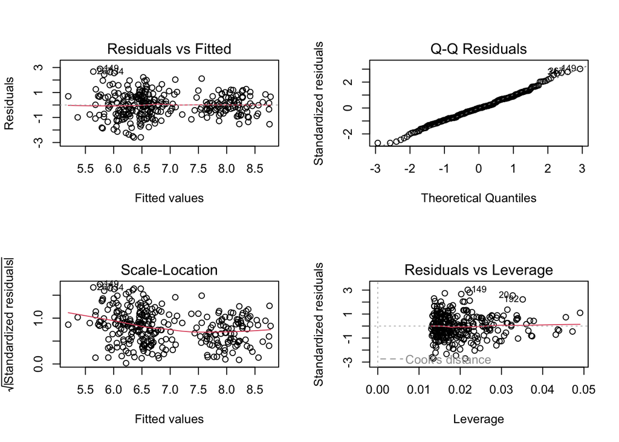

```r
# Diagnostic plots for the multiple regression model
par(mfrow = c(2, 2))
plot(linear_model)
```

```r
par(mfrow = c(1, 1))
```

The regression diagnostic plots suggest that the model assumptions were **reasonably satisfied overall, although some deviations were present**.

The **Scale-Location** plot suggested some variation in residual spread across fitted values, indicating possible mild heteroscedasticity. The **Residuals vs Leverage** plot identified several observations with relatively higher residuals or leverage, but no clearly extreme influential observations were apparent from the diagnostic plot.

Overall, the diagnostics indicate that the regression model provides a reasonable approximation of the relationships in the data, although the results should be interpreted with some caution given the observed departures from ideal model assumptions.

### 3. Interaction Between Delivery Time and SES

```r
# Interaction model
interaction_model <- lm(customer.satisfaction ~ delivery.time * SES_category + staff.satisfaction + new_range, data = cust_data_clean)

# Summary of interaction model
summary(interaction_model)
```

```
##
## Call:
## lm(formula = customer.satisfaction ~ delivery.time * SES_category +
##     staff.satisfaction + new_range, data = cust_data_clean)
##
## Residuals:
##      Min       1Q   Median       3Q      Max
## -2.69336 -0.63905 -0.02235  0.64181  2.70571
##
## Coefficients:
##                                   Estimate Std. Error t value Pr(>|t|)
## (Intercept)                       6.293471   0.751004   8.380 2.26e-15 ***
## delivery.time                    -0.036301   0.009168  -3.960 9.44e-05 ***
## SES_categoryLow                  -2.225232   0.750829  -2.964  0.00329 **
## SES_categoryMedium               -0.001146   0.742808  -0.002  0.99877
## staff.satisfaction                0.359605   0.079847   4.504 9.67e-06 ***
## new_rangeTRUE                     0.104057   0.111400   0.934  0.35103
## delivery.time:SES_categoryLow     0.032463   0.012156   2.670  0.00800 **
## delivery.time:SES_categoryMedium  0.020282   0.012478   1.625  0.10514
## ---
## Signif. codes:  0 '***' 0.001 '**' 0.01 '*' 0.05 '.' 0.1 ' ' 1
##
## Residual standard error: 0.9603 on 292 degrees of freedom
## Multiple R-squared:  0.4602, Adjusted R-squared:  0.4473
## F-statistic: 35.57 on 7 and 292 DF,  p-value: < 2.2e-16
```

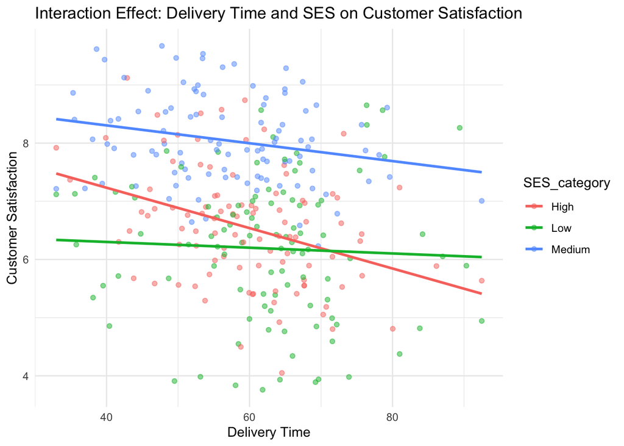

```r
# Visualization of interaction effect
ggplot(cust_data_clean, aes(x = delivery.time, y = customer.satisfaction, color = SES_category)) +
  geom_point(alpha = 0.5) +
  geom_smooth(aes(group = SES_category), method = "lm", formula = y ~ x, se = FALSE) +
  labs(title = "Interaction Effect: Delivery Time and SES on Customer Satisfaction",
       x = "Delivery Time", y = "Customer Satisfaction") +
  theme_minimal()
```

The interaction model was **statistically significant**, *F*(7, 292) = 35.57, **p < .001**, explaining approximately **46.0% of the variation in customer satisfaction** (R² = .460; adjusted R² = .447).

For **High SES stores**, which served as the reference category, longer delivery times were significantly associated with lower customer satisfaction (**b = -0.036, p < .001**).

The interaction between **delivery time and Low SES was statistically significant** (**b = 0.032, p = .008**). This indicates that the negative relationship between delivery time and customer satisfaction was **significantly weaker in Low SES stores than in High SES stores**.

The interaction between **delivery time and Medium SES was not statistically significant** (**b = 0.020, p = .105**). Therefore, there was insufficient evidence that the effect of delivery time differed significantly between Medium and High SES stores.

The interaction plot illustrates these differences: customer satisfaction declines more strongly as delivery time increases among **High SES stores**, while the relationship is considerably flatter among **Low SES stores**. The slope for Medium SES stores is also negative, but its difference from the High SES slope was not statistically significant.

Overall, the results provide evidence that **SES moderates the relationship between delivery time and customer satisfaction**, particularly when comparing **High and Low SES stores**.

## Summary

The analysis identified several operational and socio-economic factors associated with **customer satisfaction across furniture retail stores**.

The main-effects regression model explained approximately **44.7% of the variation in customer satisfaction** (R² = .447). **Longer delivery times were significantly associated with lower customer satisfaction** (**b = -0.017, p < .001**), while **higher staff satisfaction was significantly associated with higher customer satisfaction** (**b = 0.351, p < .001**).

In contrast, **new product range status was not a statistically significant predictor of customer satisfaction** (**b = 0.094, p = .404**), suggesting that operational factors such as delivery performance and staff satisfaction were more strongly associated with customer satisfaction in this dataset.

The interaction analysis further showed that **SES moderated the relationship between delivery time and customer satisfaction**. The negative association between delivery time and customer satisfaction was **significantly weaker in Low SES stores than in High SES stores** (**interaction b = 0.032, p = .008**). However, the difference between Medium and High SES stores was not statistically significant (**interaction b = 0.020, p = .105**).

From a business perspective, the findings suggest that **reducing delivery times may be particularly relevant for maintaining customer satisfaction in High SES stores**, while improving **staff satisfaction may support better customer experiences across stores more generally**. The results also suggest that introducing a new product range alone may not be sufficient to improve customer satisfaction.

Overall, the analysis demonstrates that **customer satisfaction is associated not only with operational performance but also with the socio-economic context in which stores operate**. These findings represent statistical associations and **should not be interpreted as evidence of causal relationships**.